# Stat 202: Lecture 3 (covers pp. 34-47)

Nathan VanHoudnos  
9/29/2014

### Agenda

1. Homework comments
2. Checkpoint #2 results
3. Lecture 3 (covers pp. 34-47)

### Homework comments

- 21 of you have already turned it in
  - Rock on!
- Homework #2 will be released on Wednesday

### Agenda

1. Homework comments
2. Checkpoint #2 results
3. Lecture 3 (covers pp. 34-47)

### Checkpoint #2 results

- **PSA:** Max time on a checkpoint is 2 hours
- Average percent correct: **82%**
- A little over ½ of you missed the same two questions

### Question #10, Checkpoint #2

Here again are the boxplots showing annual incomes (in thousands of dollars) for households in two cities.

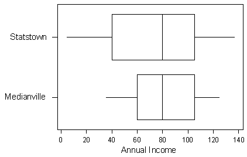

Which city has a greater percentage of households with annual incomes between $50,000 and $80,000?

### Question #14, Checkpoint #2

Here again are the boxplots showing the real estate values of single family homes in 2 neighboring cities (in thousands of dollars).

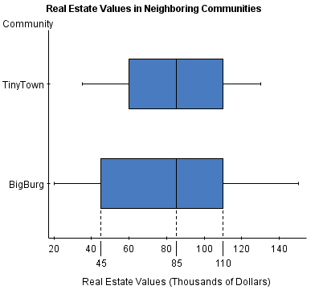

Which city has a greater percentage of homes with real estate values between $55,000 and $85,000?

### Agenda

1. Homework comments
2. Checkpoint #2 results
3. Lecture 3 (covers pp. 34-47)

### Roles and Types of variables

Roles

- **Explanatory** variables explain, predict, or affect the response (independent variable)
- The **response** variables are the outcome (dependent variable)

Types

- **Categorical** represent categories or labels
- **Quantitative** represent numerical measurements

### Role-Type examples

Are the smoking habits of a person (yes, no) related to the person's gender?

- Gender: categorical explanatory
- Smoking habits: categorical response

Is there a relationship between and test scores on a particular standardized test?

- Gender: categorical explanatory
- Test score: quantitative response

### Role-Type examples

How well can we predict a student's freshman year GPA from his/her SAT score?

- SAT score: quantitative explanatory
- GPA: quantitative response

Can you predict a person's favorite type of music based on his/her IQ?

- IQ: quantitative explanatory
- music: categorical response

### Role-Type Classification

|  |  | Response |  |
| --- | --- | --- | --- |
|  |  | Categorical | Quantitative |
| Explanatory | Categorical | \( C \rightarrow C \) | \( C \rightarrow Q \) |
|  | Quantitative | \( Q \rightarrow C \) | \( Q \rightarrow Q \) |

- \( Q \rightarrow C \)
  - **not** covered by introductory statistics
  - **extremely** important to business applications (predict decision to buy)
  - **requires post high school mathematics**
  - much of machine learning and “data science”

### $$C \rightarrow Q$$

**Age by General Health**

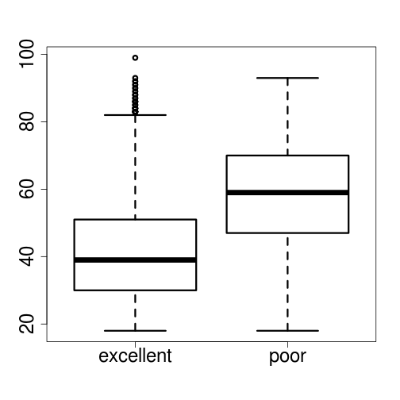

Compare the distribution of the response \( Q \) for each category of the explanatory \( C \)

**Data display**

- side-by-side boxplots

**Numeric summaries**

- descriptive statistics

### $$C \rightarrow Q$$

**Age by General Health**

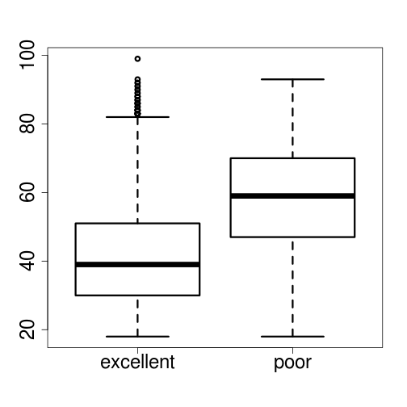

**Example**

- **Center:** The median poor respondent is 60 years old while the median excellent respondent is 40 years old.
- **Relative 5 number:** In fact, approximately ¾ of poor respondents are as old or older than the oldest ¼ of excellent respondents.

### $$C \rightarrow C$$

Are men and women just as likely to think their weight is about right?

**Two-way** table:

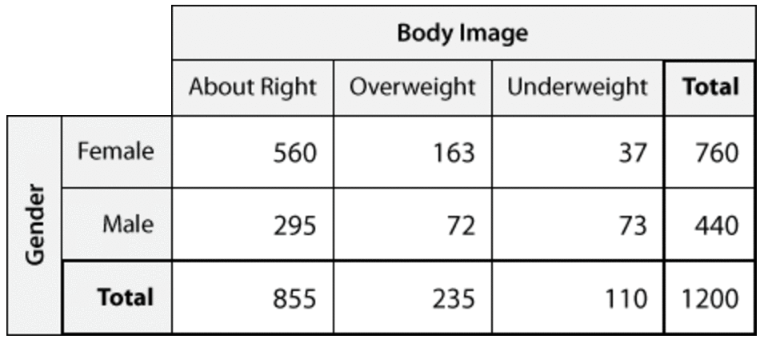

### $$C \rightarrow C$$

**Marginal distribution** of Body Image

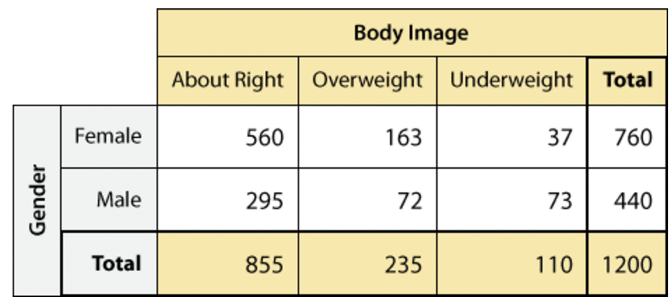

### $$C \rightarrow C$$

**Marginal distribution** of Gender

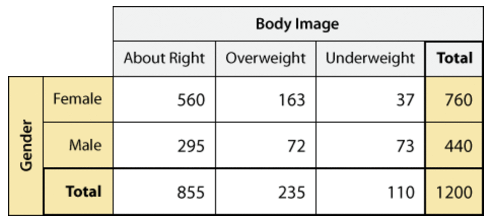

### $$C \rightarrow C$$

**Joint distribution** of Gender and Body Image

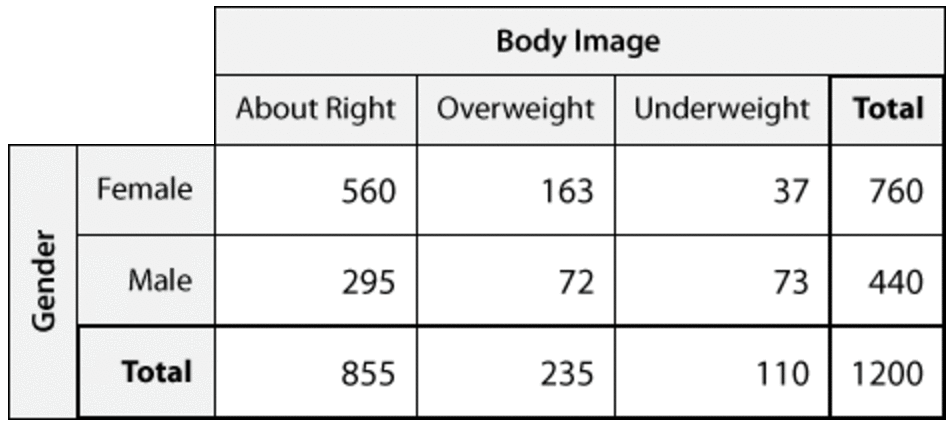

### Visualizing Joint distribution

**Joint Distribution**

```
        body.image
gender   Underweight About Right Overweight
  Female          37         560        163
  Male            73         295         72
```

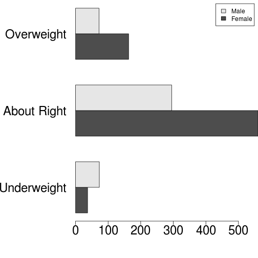

### $$C \rightarrow C$$

Are men and women just as likely to think their weight is about right?

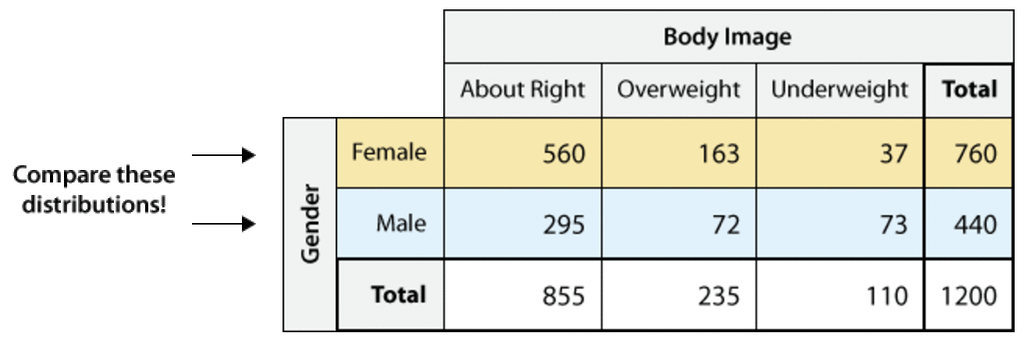

**How?**

### Conditional distributions

What is the distribution of body image **conditional** on gender?

**Step 1:** Identify the conditioning variable. (gender)

**Step 2:** Calculate **conditional proportions** (or %)

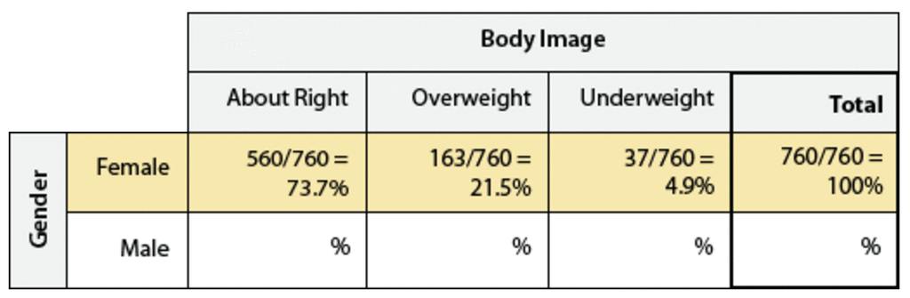

Calculate: Male | 295 | 72 | 73 | Total: 440

### Conditional distributions

What is the distribution of body image **conditional** on gender?

**Step 1:** Identify the conditioning variable. (gender) **Step 2:** Calculate **conditional proportions** (or %)

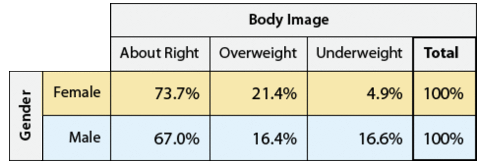

- These are **conditional row** percentages.

### Viz. conditional distributions

Body image **conditional** on gender

```
        body.image
gender   Underweight About Right Overweight
  Female       0.049       0.737      0.214
  Male         0.166       0.670      0.164
```

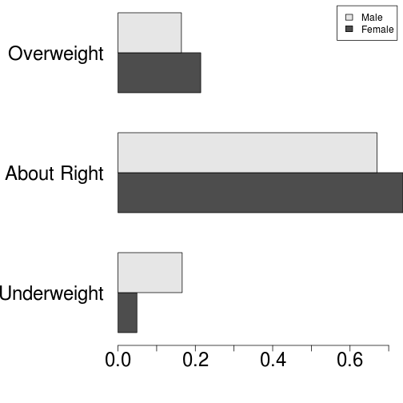

### Which type of table?

Is the smoking of students related to their parents' smoking habits?

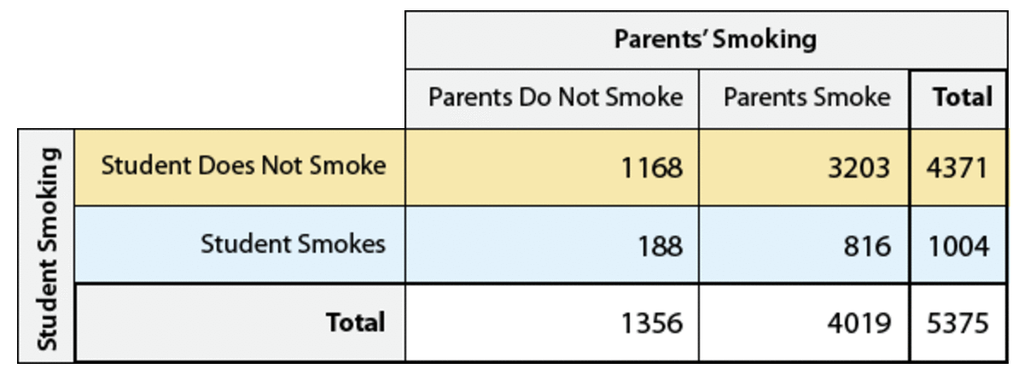

- **Question:** Joint? Conditional row? Conditional column?

### Which type of table?

Is the smoking of students related to their parents' smoking habits?

1. **Identify roles**
   - Response: student smoking
   - Explanatory: parent smoking
2. **Which variable to condition on?**
   - Always condition *response* by *explanatory*
   - Condition student smoking by parent smoking
3. **Calculate table**

### Which type of table?

Is the smoking of students related to their parents' smoking habits?

- Conditional table: student smoking by parent smoking

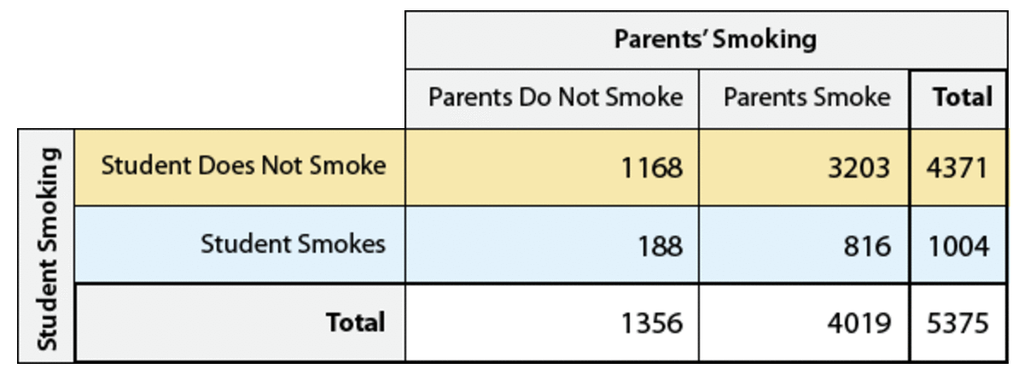

### Which type of table?

Is the smoking of students related to their parents' smoking habits?

- Conditional table: student smoking by parent smoking

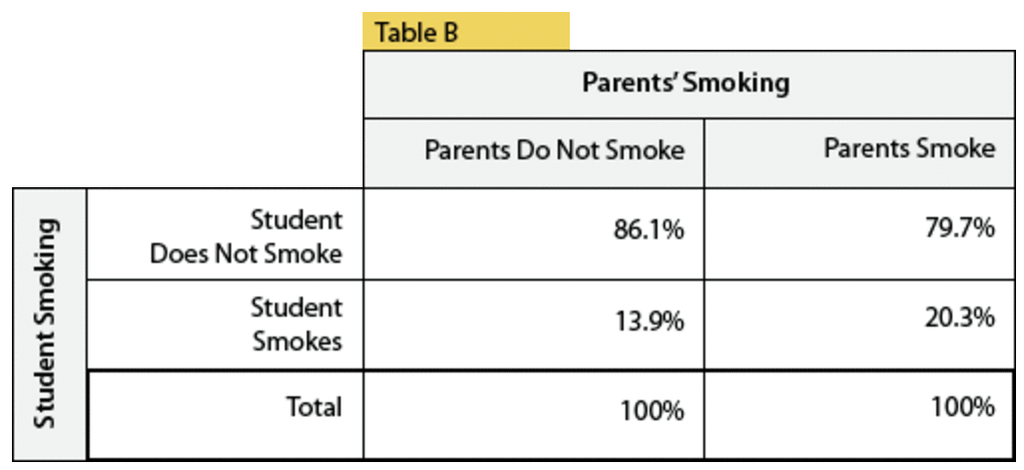

### $$C \rightarrow C$$

**Body image by Gender**

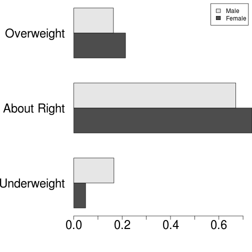

Compare the distribution of the response \( C \) for each category of explanatory \( C \)

**Data display**

- double bar chart

**Numeric summaries**

- conditional proportions table

### $$Q \rightarrow Q$$

What is the effect of age on maximum legibility distance of a road sign?

- age: quantitative explanatory
- distance: quantitative response

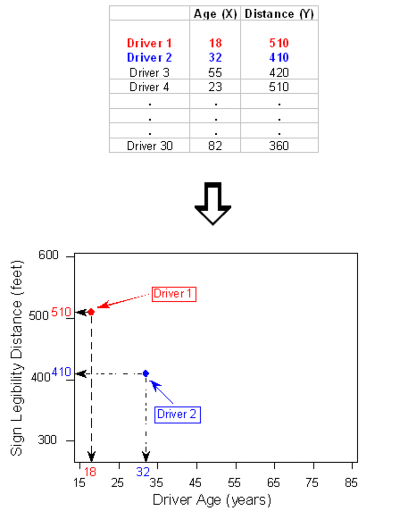

### Scatterplot

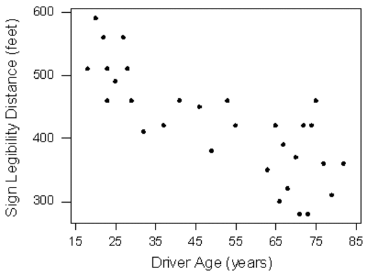

- Explantory on x-axis
- Response on y-axis

Interpretation:

- Direction
- Form
- Strength
- Any outliers?

### Direction

**Positive**

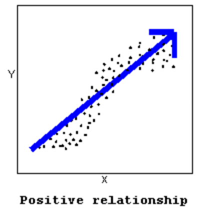

**Negative**

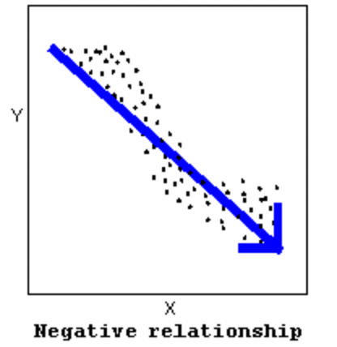

### Direction

**Neither**

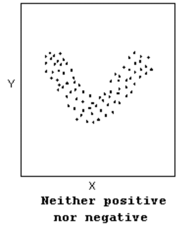

**Comments**

- positive need not be linear
- negative need not be linear
- neither could be
  - U shaped
  - flat
  - circle
  - etc.

### Form

**Linear**

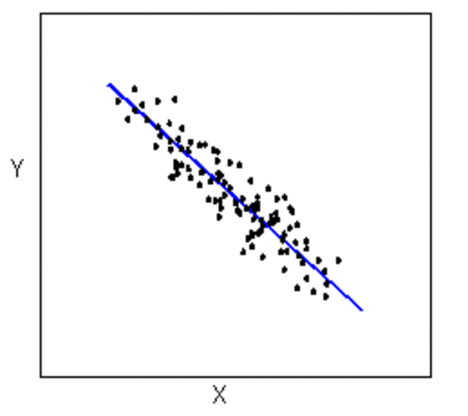

**Curvilinear**

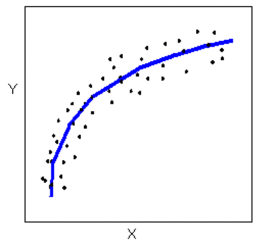

### Form

**Clustered**

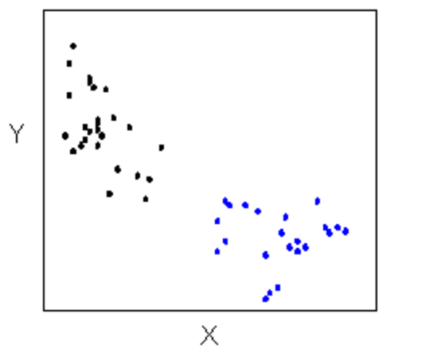

**Comments**

- many other forms are possible
- we focus mostly on **linear**

### Strength

**Strong**

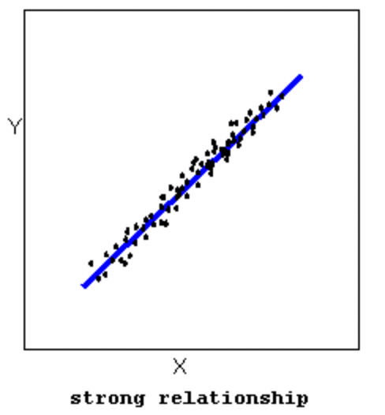

**Weak**

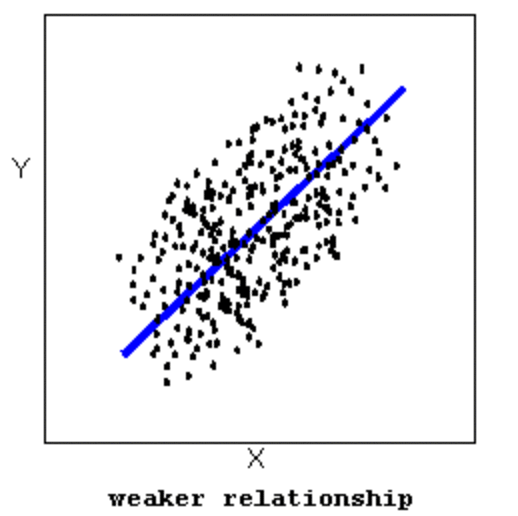

### Deviations from pattern?

**Two outliers**

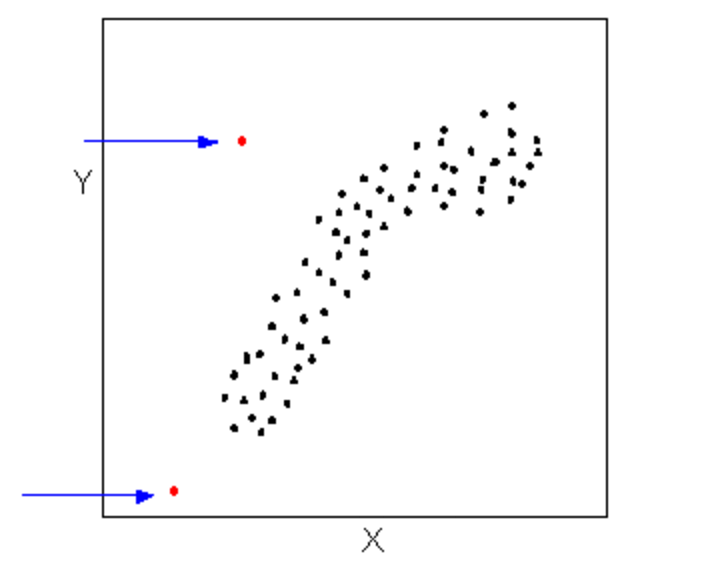

Two types of outliers:

- follow pattern
  - example: bottom outlier
- break pattern
  - example: top outlier

### Age and Driving Redux

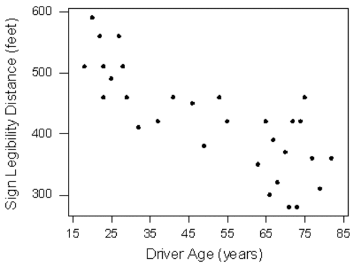

**Direction**

- negative

**Form**

- linear

**Strength**

- moderate strength

**Any outliers?**

- none

### $$ \left\{ Q, C \right\} \rightarrow Q $$

**Labeled scatterplot**

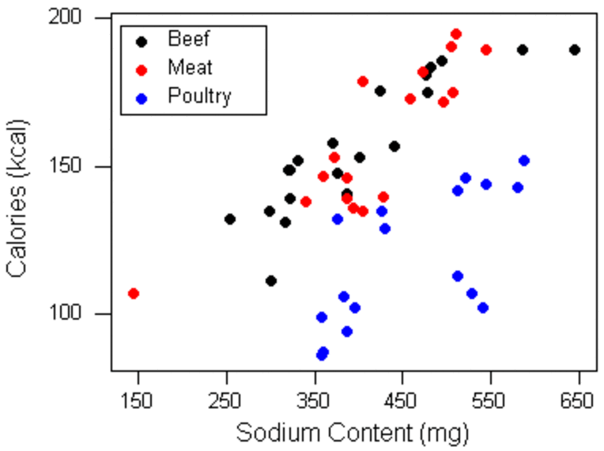

Split explanatory \( Q \) by additional \( C \)

- sodium content: \( Q \) explanatory
- meat type: (additional) \( C \) explanatory
- calories: \( Q \) response

See p. 47 for full example

### Role-Type Classification

|  |  | Response |  |
| --- | --- | --- | --- |
|  |  | Categorical | Quantitative |
| Explanatory | Categorical | \( C \rightarrow C \) | \( C \rightarrow Q \) |
|  | Quantitative | \( Q \rightarrow C \) | \( Q \rightarrow Q \) |

- \( C \rightarrow C \) : tables and double bar charts
- \( C \rightarrow Q \) : boxplot
- \( Q \rightarrow C \) : (not discussed)
- \( Q \rightarrow Q \) : scatterplot